# TU059/TU060/TU256/PhD (Delete as appropriate) Probability and Statistical Inference

Multiple Linear Regression

```r
# ---- Load (and install if needed) required packages ----
packages <- c(
  "stats",        # Core R statistical functions (cor.test, oneway.test, bartlett.test)
  "car",          # Companion to Applied Regression (Levene’s test, outlier diagnostics)
  "rstatix",      # User-friendly statistical tests (Tukey HSD post-hoc)
  "effectsize",   # Computes and interprets effect sizes (e.g., eta squared, Cohen’s d)
  "psych",        # Descriptive statistics for grouped data (describeBy)
  "ggplot2",      # Data visualization (histograms, QQ plots, diagnostic plots)
  "VIM",          # Visualization of missing data patterns (aggr)
  "kableExtra",   # Enhances tables created with knitr::kable (styling, layout)
  "knitr",        # Generates formatted tables and report outputs (kable)
  "performance",  # Regression diagnostics and model checks (check_model, check_normality)
  "lm.beta"       # Computes standardized beta coefficients for linear models
)

quiet_library <- function(pkg) {
  suppressMessages(suppressWarnings({
    if (!requireNamespace(pkg, quietly = TRUE)) {
      install.packages(pkg, dependencies = TRUE)
    }
    library(pkg, character.only = TRUE)
  }))
}
# Apply the function to load the packages
lapply(packages, quiet_library)
```

[output not shown]

[output cut: 55 more lines]

```r
#Amend this to reflect your folder structure
datalocation <- file.path("C:","Users", "deirdre.lawless", "datafiles")
datapath <- file.path(datalocation,'survey.dat')

#Load data
sdata <- read.table(datapath)
colnames(sdata) <- tolower(colnames(sdata))

#Filter out the variables of interest to this analysis
myvars <- c("tpcoiss", "tpstress", "toptim", "tlifesat", "marital", "educ")
sdata <-sdata[myvars]
```

Notes: 1: This is an example. It is intended to demonstrate how to put together a report together on multiple linear regression for phase 2 of the CA. This does not mean you should follow it religiously for your report. You are expected to replace content to suit your dataset and replace comments to express your usage of functions. You can change the structure to suit your process as long as you address all the aspects included in this report.

2: All the statistics generated for the reporting of data exploration and the regression model building and diagnostic checking are included within the analysis, you can include in an Appendix if you wish.

3: This code uses a set of functions which are imported. These are in MATH9102-W9-Functions.R and this file should be located in the same folder as this rmd script. If you have any problems with this just cut and paste the functions into a R chunk in this script - include them just after where you load the data.

# 1. Introduction

This statistical analysis investigates whether a range of psychological and demographic factors impact on a person’s psychological well-being, in particular their level of optimism. This analysis aims to investigate the following research question:

Can psychological factors, in particular perceived sense of control, level of perceived stress and life satisfaction, predict an individual’s level of optimism?

Additionally, the analysis seeks to explore whether a differential effect exist in this prediction for respondents of different marital status.

The dataset used contains data collected from 439 respondents who completed a survey as part of a study to explore the factors that impact on respondents’ psychological adjustment and well-being. The study was distributed to members of the general public in Melbourne, Australia and surrounding districts made available by Pallant (2020).

Throughout the analysis, a significance threshold of 0.05 was used, and effect sizes were reported according to Cohen’s conventions(1988). Before interpreting the multiple linear regression results, diagnostic checks were conducted to ensure compliance with the key statistical assumptions underpinning the analysis. These included tests for linearity, normality of residuals, homoscedasticity, multicollinearity, and the presence of outliers, leverage points, or influential observations (Field, Miles, & Field, 2021; Tabachnick & Fidell, 2019). Linearity and homoscedasticity were assessed through examination of residual plots, where a random distribution of residuals around the zero line indicated that the assumptions were met. The normality of residuals was evaluated both visually, using Q–Q plots, and statistically, with small deviations tolerated given the robustness of regression to minor non-normality in larger samples (Field et al., 2021). Standardized residuals were inspected to identify potential outliers, with absolute values exceeding ±3.29 considered cause for further investigation (Tabachnick & Fidell, 2019). To assess influence, Bonferroni-adjusted tests of studentized residuals and Cook’s distance statistics were applied; Cook’s distance values greater than 1.0 were regarded as indicative of influential outliers, while leverage values were examined to identify cases exerting disproportionate influence on the regression coefficients (Belsley, Kuh, & Welsch, 1980; Field et al., 2021). Multicollinearity was assessed using Variance Inflation Factor (VIF) and Tolerance values. Following Field, Miles, and Field (2021), VIF values greater than 5 or Tolerance values below 0.2 were considered indicative of potential multicollinearity, while more extreme thresholds (VIF > 10, Tolerance < 0.1) would indicate serious violations. Collectively, these diagnostic procedures confirmed that the data met the necessary assumptions for valid multiple regression analysis, providing confidence in the reliability of the model estimates.

# 2. Data Description

The dataset consists of 439 rows and 134 columns containing the responses from survey respondents. The survey contained a variety of validated scales measuring constructs chosen from the extensive literature on psychological well being. The scales measured respondents’ self-esteem, optimism, perceptions of control, perceived stress, positive and negative affect, life satisfaction and tendency to present themselves in a socially desirable manner. In addition a range of demographic information including gender, marital status, parental status, education level and information on smoking habits was also collected. The concepts of interest in this analysis represent only a subset of the dataset. The concepts of interest, their measurement and statistical type are shown in Tables 1 and 2 below.

```r
# create the table using kable
data.frame(
Concept = c("Optimism",
"Perceived Control of Internal States",
"Perceived Stress",
"Life Satisfaction"),
`Scale Used` = c(
"6-item Life Orientation Test (Scheier & Carver, 1985)",
"18-item PCOISS (Pallant, 2000)",
"10-item Perceived Stress Test (Cohen, Kamarck & Mermelstein, 1983)",
"5-item Satisfaction with Life (Diener et al., 1985)"
),
Type = "Continuous – Ratio"
) |>
kable()
```

Table 1: Psychological Factors of Interest

| Concept | Scale.Used | Type |
| --- | --- | --- |
| Optimism | 6-item Life Orientation Test (Scheier & Carver, 1985) | Continuous – Ratio |
| Perceived Control of Internal States | 18-item PCOISS (Pallant, 2000) | Continuous – Ratio |
| Perceived Stress | 10-item Perceived Stress Test (Cohen, Kamarck & Mermelstein, 1983) | Continuous – Ratio |
| Life Satisfaction | 5-item Satisfaction with Life (Diener et al., 1985) | Continuous – Ratio |

| Concept | Possible Values | Type |
| --- | --- | --- |
| Marital Status | 1. single, 2. in a steady relationship, 3. living with partner, 4. married for first time, 5. remarried, 6. separated, 7. divorced, 8. widowed | Nominal |

```r
data.frame(
Concept = "Marital Status",
`Possible Values` = "1. Single, 2. In a steady relationship, 3. Living with partner, 4. Married for first time, 5. Remarried, 6. Separated, 7. Divorced, 8. Widowed",
Type = "Nominal"
) |>
kable()
```

Table 2: Demographic Factors of Interest

| Concept | Possible.Values | Type |
| --- | --- | --- |
| Marital Status | 1. Single, 2. In a steady relationship, 3. Living with partner, 4. Married for first time, 5. Remarried, 6. Separated, 7. Divorced, 8. Widowed | Nominal |

## 2.1 Missing Data

The data for each of the concepts of interest was inspected to establish whether the level of missing data represented a source of bias. Using the guidance of Tabachnick and Fidell (2016) neither the proportion nor pattern of missing data represent a source of concern see Figure 1, and any decision on missing data treatment would not significantly impact the results. All missing data was therefore removed before the analysis.

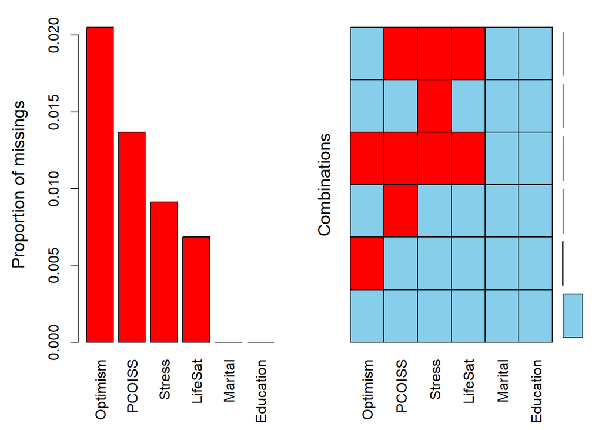

Figure 1: Inspection of Missing Data

```
 Variables sorted by number of missings:
  Variable       Count
  Optimism 0.020501139
    PCOISS 0.013667426
    Stress 0.009111617
   LifeSat 0.006833713
   Marital 0.000000000
 Education 0.000000000
```

```r
mdata <- sdata
colnames(mdata) <- c(
  "Optimism",
  "PCOISS",
  "Stress",
  "LifeSat",
  "Marital",
  "Education"
)
res<-summary(VIM::aggr(mdata, sortVar=TRUE, combined=FALSE))$combinations
```

```r
sdata <- na.omit(sdata)
sdata$ztpcoiss  <- abs(scale(sdata$tpcoiss))
#Removing the two rows with tpcoiss > 3.29
sdata <- sdata[sdata$ztpcoiss <= 3.29, ]
```

## 2.2 Pyschological Factors

The distribution of all the psychological factors were inspected to determine if that distribution could be considered to approximate the normal distribution. Using the guidance of Curran, West and Finch (1996) a distribution with standardized skewnesss or kurtosis between +/- 2 was considered approximately normal. Absolute scores were examined to identify to whether outliers were a problem at a univariate level. Using the guidance of Field, Miles and Field (2012), if 98% of the data fell between +/- 3.29 the distribution was considered to be approximately normal.

For Total Perception of Control, 99.53% of z-scores fell within ±3.29; the two cases exceeding this threshold were removed. The resulting data then met the criterion of 99.7% of scores falling within ±3.29 and were therefore considered normal.

Details of all statistics used to assess the distribution, along with the appropriate descriptive statistics for these variables, are presented in Table 3.

```r
# Generate statistics needed for normality assessment using analyze_ratio_variable function
result3 <- analyze_ratio_variable(sdata, "toptim")
result1 <-analyze_ratio_variable(sdata, "tpstress")
result2 <- analyze_ratio_variable(sdata, "tpcoiss")
result4 <- analyze_ratio_variable(sdata, "tlifesat")
```

| Concept | Standardized Skew | Standardized Kurtosis | % of Absolute Scores Outside ±3.29 | Descriptive Statistics |
| --- | --- | --- | --- | --- |
| Total Optimism | 3.78 | 0.6 | 0.24 | M: 22.21 SD: 4.32 |
| Total Perceived Stress | 1.77 | 0.09 | 0 | M: 26.66 SD: 5.74 |
| Total Perception of Control | 2.54 | 0.05 | 0 | M: 60.77 SD: 11.67 |
| Total Life Satisfaction | 2.23 | 2.24 | 0 | M: 22.5 SD: 6.65 |

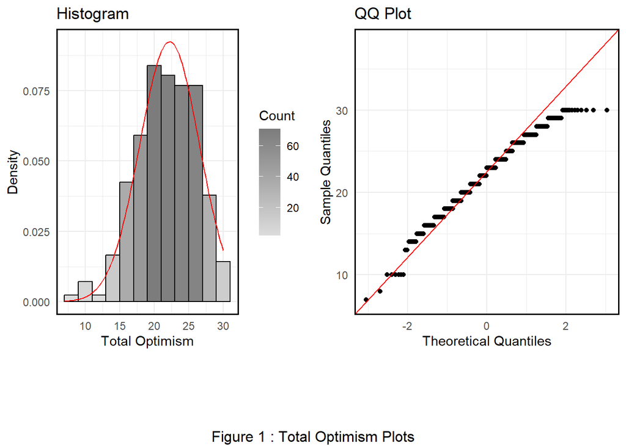

```r
# Generate plots using function plot_ratio_variable
plot_ratio_variable(sdata, "toptim", "Total Optimism", 1)
```

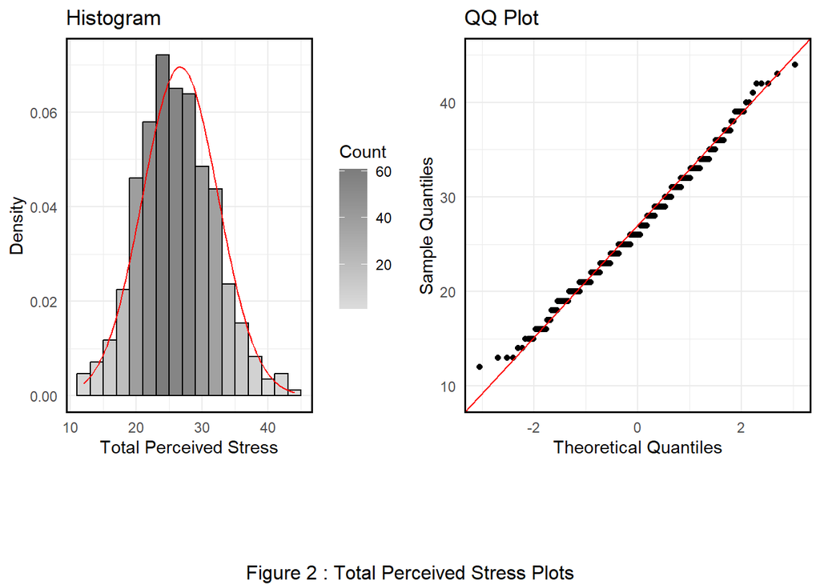

```r
plot_ratio_variable(sdata, "tpstress","Total Perceived Stress",2)
```

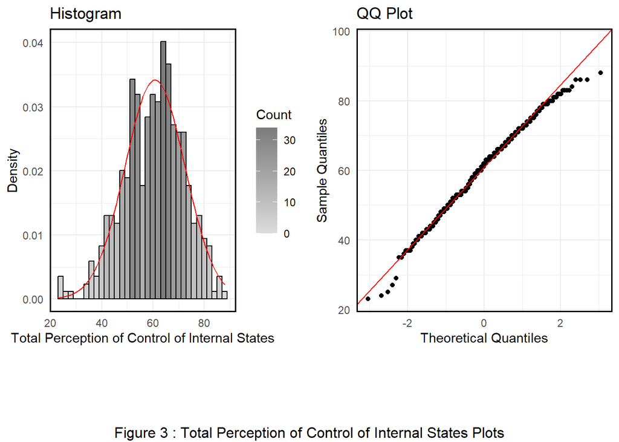

```r
plot_ratio_variable(sdata, "tpcoiss", "Total Perception of Control of Internal States", 3)
```

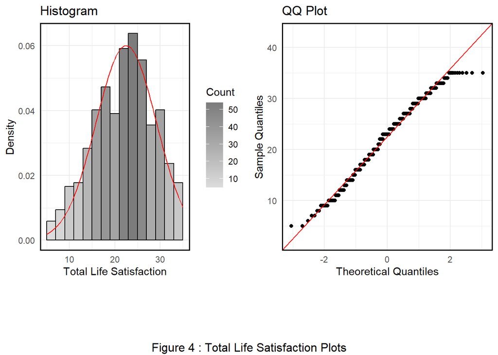

```r
plot_ratio_variable(sdata, "tlifesat", "Total Life Satisfaction", 4)
```

## 2.3 Marital Status

The proportions of respondents for each of the eight categories of marital status are shown below in Table 4.

```r
# Create and format the frequency table
count_data <- as.data.frame(table(sdata$marital))
count_data <- count_data[order(count_data$Freq), ]

# Rename columns (avoid spaces in names)
colnames(count_data) <- c("Marital_Status", "Count")

# Generate the table
knitr::kable(count_data, caption = NULL) |>
  kableExtra::kable_styling(bootstrap_options = c("striped", "hover"))
```

Table 4: Frequency Table – Marital Status

|  | Marital_Status | Count |
| --- | --- | --- |
| 8 | WIDOWED | 7 |
| 5 | SEPARATED | 10 |
| 1 | DIVORCED | 24 |
| 4 | REMARRIED | 29 |
| 2 | LIVING WITH PARTNER | 34 |
| 7 | STEADY RELATIONSHIP | 37 |
| 6 | SINGLE | 99 |
| 3 | MARRIED FIRST TIME | 183 |

The dataset has a higher proportion of individuals in a relationship (Living with a partner, Married first time, remarried steady relationship). Those not in a relationship (Divorced, Separated, Single, Widowed) are therefore underrepresented. This imbalance may lead to over generalization, as the experiences and perspectives of individuals not in a relationship could differ significantly. Additionally, “Widowed” (7) and “Separated” (10), have small group sizes, which could limit the generalizability of findings for these categories. These limitations will be taken into account when assessing the overall usefulness of the linear models built.

## 2.4 Exploratory Data Analysis

The relationships between the concepts of interest were investigated before linear regression models were constructed to ensure that a linear relationship could be considered to exist between the proposed dependent variable and proposed predictors.

```r
r1=stats::cor.test(sdata$tpstress, sdata$toptim)
r2=stats::cor.test(sdata$tpcoiss, sdata$toptim)
r3=stats::cor.test(sdata$tlifesat, sdata$toptim)
```

```r
# Create a data frame for the correlation results

corr_table <- data.frame(
Dependent = c("Optimism", "Optimism", "Optimism"),
Predictor = c("Perceived Stress", "Perception of Control", "Life Satisfaction"),
`Correlation Coefficient (r)` = c(
round(r1$estimate, 2),
round(r2$estimate, 2),
round(r3$estimate, 2)
),
Significance = c("p < 0.001", "p < 0.001", "p < 0.001")
)

knitr::kable(
corr_table)
```

Table 5: Correlations between Total Optimism and other Psychological Factors

| Dependent | Predictor | Correlation.Coefficient..r. | Significance |
| --- | --- | --- | --- |
| Optimism | Perceived Stress | -0.45 | p < 0.001 |
| Optimism | Perception of Control | 0.49 | p < 0.001 |
| Optimism | Life Satisfaction | 0.49 | p < 0.001 |

```r
#Get descriptive statistics by group - output as a matrix
optdesc<-psych::describeBy(sdata$toptim, sdata$marital, mat=TRUE)

#Conduct Bartlett's test for homogeneity of variance
stats::bartlett.test(toptim~ marital, data=sdata)
```

```
    Bartlett test of homogeneity of variances

data:  toptim by marital
Bartlett's K-squared = 2.7474, df = 7, p-value = 0.9073
```

```r
#Conduct ANOVA using the one-way ANOVA from the stats package
res <- stats::oneway.test(toptim ~ as.factor(marital), data = sdata, var.equal = TRUE)

#We use Tukey for post-hoc testing
tukeyres <-rstatix::tukey_hsd(sdata, toptim ~ marital)

#Compute our Eta squared
effes=effectsize::effectsize(res)
effes
```

```
Eta2 |       95% CI
-------------------
0.04 | [0.00, 1.00]

- One-sided CIs: upper bound fixed at [1.00].
```

```r
#Store the relevant pieces of the output from ANOVA in variables to use for reporting
#Degrees of freedom
df1=res$parameter[1]
df2=res$parameter[2]
#F statistic
Fstat=round(res$statistic, 3)
#Pvalue
pval=round(res$p.value,2)
```

A one-way between-groups analysis of variance (ANOVA) was conducted to explore the impact of marital status on levels of optimism. There was a statistically significant difference at the p < .05 level in optimism scores for different marital status: (F(7, 415)= 2.515, p<0.05.

Despite reaching statistical significance, the actual difference in mean scores between groups was small, (eta squared = 0.04). Post-hoc comparisons using the Tukey HSD test indicated that a statistically significant difference existed only between respondents who were separated (M=18.5,SD=4.99) differed significantly from those who were widowed (M=25.57,SD=4.31).

# 3. Predicting Optimism: The Impact of Control, Stress, and Life Satisfaction.

This section discusses the multiple linear regression model developed to investigate the extent to which psychological factors—specifically perceived sense of control, perceived stress levels, and life satisfaction—can be considered to predict an individual’s level of optimism. The model’s fit and usefulness are examined, followed by a rigorous assessment of how it meets the assumptions of linear regression to ensure the reliability of the findings. Finally, the impact of each psychological factor on optimism and the model’s predictive power are evaluated, culminating in a discussion of the implications of these results.

## 3.1 Model Fitting

All predictors were statistically significant: total perceived stress (p < 0.05), total perception of control (p < 0.001), and total life satisfaction (p < 0.001).

## 3.2 Model Diagnostics

```r
# Define the list of model variables
mvars <- c("toptim", "tpstress", "tpcoiss", "tlifesat")

# Calculate the variance for each  and store it in varp
varp <- sapply(mvars, function(p) round(var(sdata[[p]], na.rm = TRUE), 2))  # Round the variance to 2 decimal places
```

```r
# Check normality - conducts a Shapiro-Wilks test and checks the standardized residuals for normal distribution
# A p-value < 0.05 indicates a significant deviation from normal distribution.

performance::check_normality(model1)
```

```
OK: residuals appear as normally distributed (p = 0.438).
```

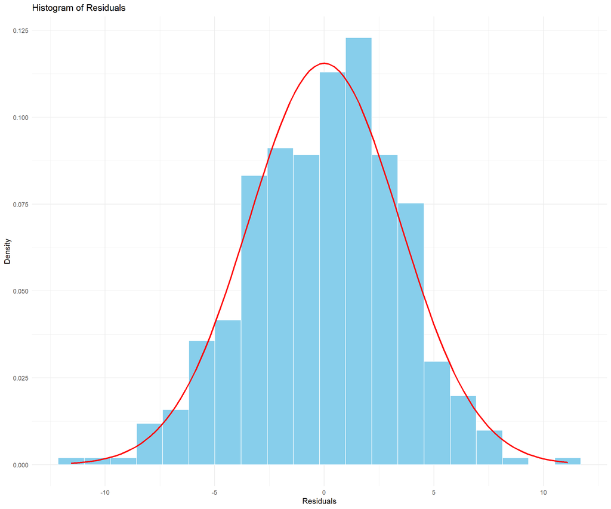

Residual Distribution Plots for Model 1

```r
# Visualize residual distribution


# Histogram of Residuals
ggplot(data.frame(residuals = resid(model1)), aes(x = residuals)) +
  geom_histogram(aes(y = ..density..),
                 bins = 20,
                 fill = "skyblue",
                 color = "white") +
  stat_function(fun = dnorm,
                args = list(mean = mean(resid(model1)), sd = sd(resid(model1))),
                color = "red",
                linewidth = 1) +
  labs(title = "Histogram of Residuals",
       x = "Residuals",
       y = "Density") +
  theme_minimal()
```

```
For confidence bands, please install `qqplotr`.
```

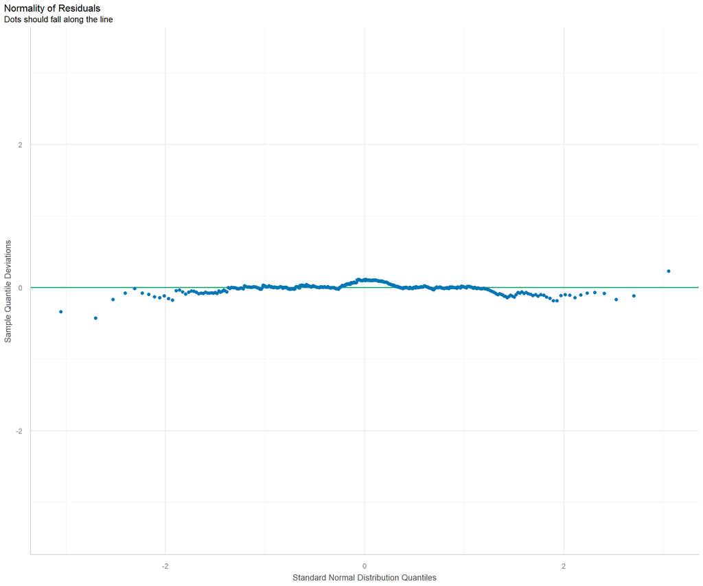

Residual Distribution Plots for Model 1

```r
# A transformed version of a Q–Q plot displayed horizontally
plot(check_normality(model1))
```

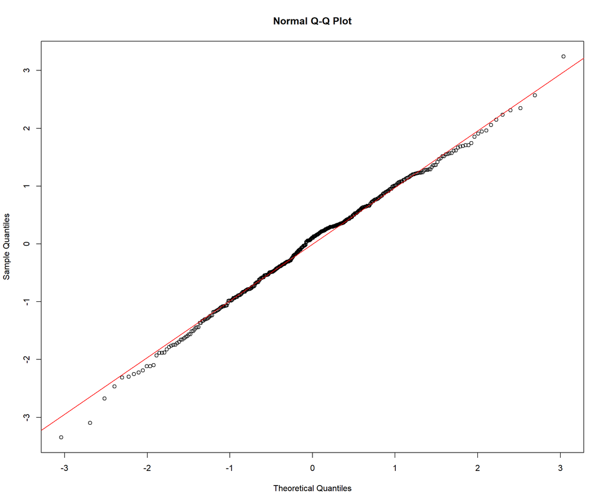

Residual Distribution Plots for Model 1

```r
# Q-Q plot of standardized residuals
qqnorm(rstandard(model1))
qqline(rstandard(model1), col = "red")
```

```r
# Check for outliers or influential points

performance::check_outliers(model1)
```

```
OK: No outliers detected.
- Based on the following method and threshold: cook (0.841).
- For variable: (Whole model)
```

```r
# Extract residuals
residuals <- resid(model1)

# Standardize the residuals
std_residuals <- residuals / sd(residuals)

# Calculate max and min of the standardized residuals
max_std_residual <- max(std_residuals)
min_std_residual <- min(std_residuals)

# Print the results
cat("Max standardized residual:", max_std_residual, "\n")
```

```
Max standardized residual: 3.220051
```

```r
cat("Min standardized residual:", min_std_residual, "\n")
```

```
Min standardized residual: -3.344049
```

```r
#Identify potential outliers in the dataset based on the studentized residuals of the model.
car::outlierTest(model1) # Bonferonni p-value for most extreme observations - observations with a p value lower than the threshold are consider outliers.
```

```
No Studentized residuals with Bonferroni p < 0.05
Largest |rstudent|:
     rstudent unadjusted p-value Bonferroni p
276 -3.386738         0.00077426      0.32751
```

```r
# In this case there are none
```

```r
performance::check_heteroscedasticity(model1)
```

[output not shown]

```r
# Check multicollinearity

performance::check_collinearity(model1)
```

```
# Check for Multicollinearity

Low Correlation

     Term  VIF   VIF 95% CI adj. VIF Tolerance Tolerance 95% CI
 tpstress 1.68 [1.49, 1.95]     1.30      0.59     [0.51, 0.67]
  tpcoiss 1.48 [1.32, 1.70]     1.22      0.68     [0.59, 0.75]
 tlifesat 1.32 [1.20, 1.52]     1.15      0.76     [0.66, 0.84]
```

```r
mcresults <-performance::check_collinearity(model1)
```

The residual diagnostic plots are shown in Figure 7. The model residuals showed a satisfactory distribution with a density plot resembling normality although minor deviations were observed in the QQ plot indicating slight non-normality in the residuals (max=3.2200511, min=-3.3440489). However, examination of residuals using the guidance of Field, Miles and Field (2012) identified no residual with Cook’s distance greater than 1. While one potential leverage point was identified, on inspection, the observation was considered valid and retained. The distribution of residuals can therefore be considered normal.

Tests to check if the data met the assumption of collinearity indicated that multicollinearity was not a concern (total perceived stress VIF=1.6841984, Tolerance = 0.5937543; total perception of control VIF=1.4769965, Tolerance = 0.6770497; total life satisfaction VIF=1.3181672, Tolerance = 0.7586291).

The model can be considered to meet the assumptions of multiple linear regression, including linearity, normality of residuals, homoscedasticity, and low multicollinearity, with minimal concerns about influential points. The model diagnostics suggest therefore that the model provides a reliable estimate of the relationship between total optimism, total perceived stress, total perception of control, and total life satisfaction.

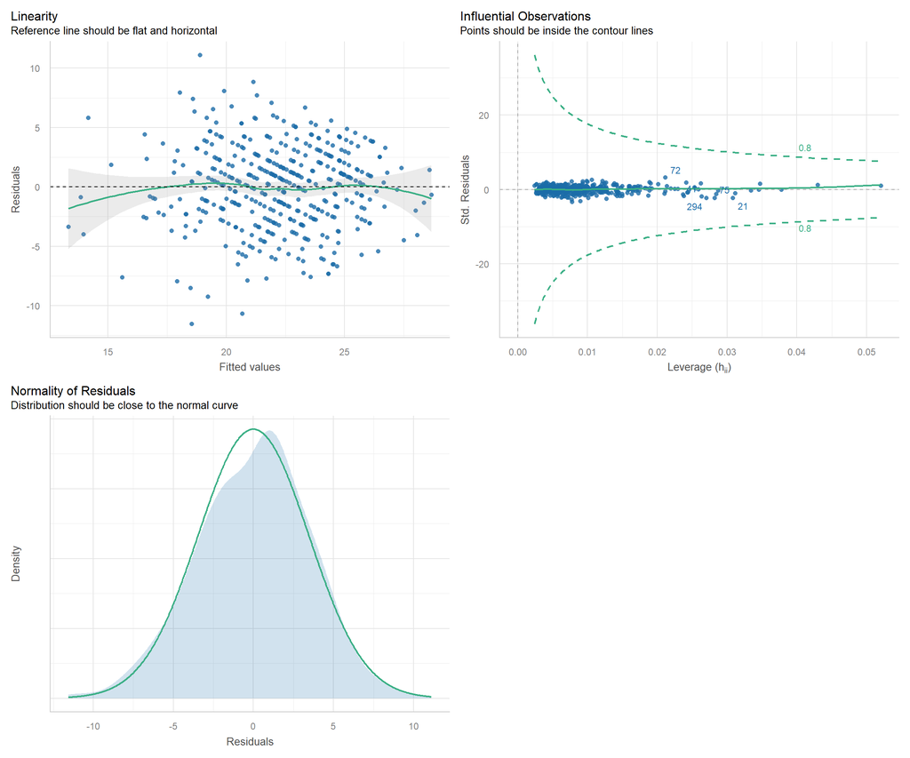

Figure 7 - Diagnostic plots for Model 1

```r
# Overall diagnostic plots

# If using R 4.4.x use
performance::check_model(model1,
  check = c(
    "linearity",
    "homoscedasticity",
    "outliers",
    "collinearity",
    "normality"
  )
)
```

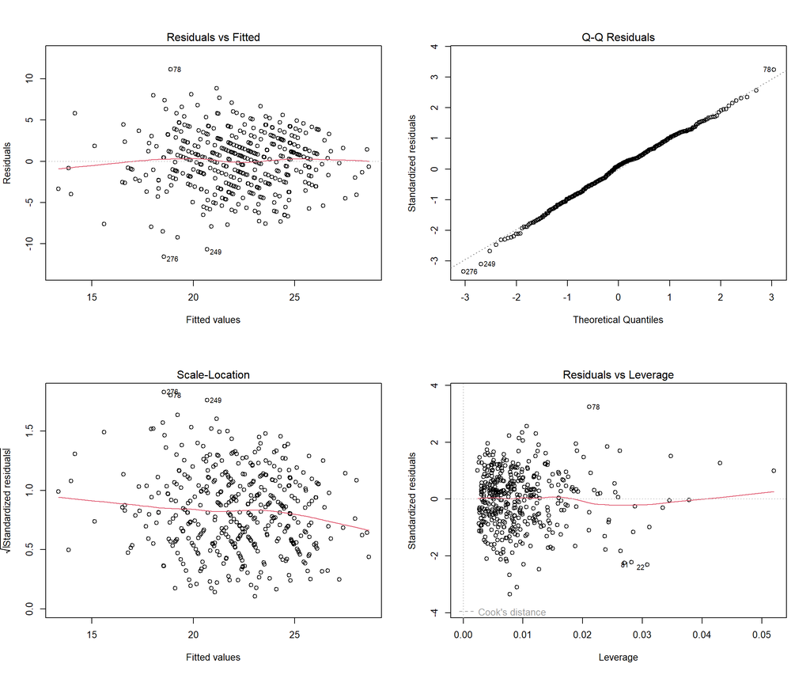

Figure 7 - Diagnostic plots for Model 1

```r
# If using R 4.5.x Show all 4 diagnostic plots in one figure using R basic plots
par(mfrow = c(2, 2))   # 2x2 grid layout
plot(model1)            # Generates: Residuals vs Fitted, Normal Q-Q, Scale-Location, Cook’s distance
```

```r
par(mfrow = c(1, 1))    # Reset layout
```

## 3.3 Results and Interpretation

# 4.Role of Marital Status in Predicting Optimism from Psychological Factors

```r
# Fit the linear regression model
model2 <- lm(toptim ~ tpstress + tpcoiss + tlifesat + marital, data = sdata)
summary(model2)
```

```
Call:
lm(formula = toptim ~ tpstress + tpcoiss + tlifesat + marital,
    data = sdata)

Residuals:
     Min       1Q   Median       3Q      Max
-11.4400  -2.3152   0.3711   2.2799  11.0036

Coefficients:
                           Estimate Std. Error t value Pr(>|t|)
(Intercept)                13.52189    2.24731   6.017 3.93e-09 ***
tpstress                   -0.08616    0.03890  -2.215   0.0273 *
tpcoiss                     0.11309    0.01845   6.128 2.08e-09 ***
tlifesat                    0.20521    0.03030   6.772 4.39e-11 ***
maritalLIVING WITH PARTNER -0.55783    0.96647  -0.577   0.5641
maritalMARRIED FIRST TIME  -0.42788    0.78540  -0.545   0.5862
maritalREMARRIED           -0.63948    0.98344  -0.650   0.5159
maritalSEPARATED           -1.67671    1.32796  -1.263   0.2074
maritalSINGLE              -0.67372    0.80772  -0.834   0.4047
maritalSTEADY RELATIONSHIP -0.46995    0.94269  -0.499   0.6184
maritalWIDOWED              0.33428    1.51523   0.221   0.8255
---
Signif. codes:  0 '***' 0.001 '**' 0.01 '*' 0.05 '.' 0.1 ' ' 1

Residual standard error: 3.485 on 412 degrees of freedom
Multiple R-squared:  0.3648,    Adjusted R-squared:  0.3494
F-statistic: 23.66 on 10 and 412 DF,  p-value: < 2.2e-16
```

## 4.2 Model Diagnostics

```r
# Check normality - conducts a Shapiro-Wilks test and checks the standardized residuals for normal distribution
# A p-value < 0.05 indicates a significant deviation from normal distribution.

performance::check_normality(model2)
```

```
OK: residuals appear as normally distributed (p = 0.534).
```

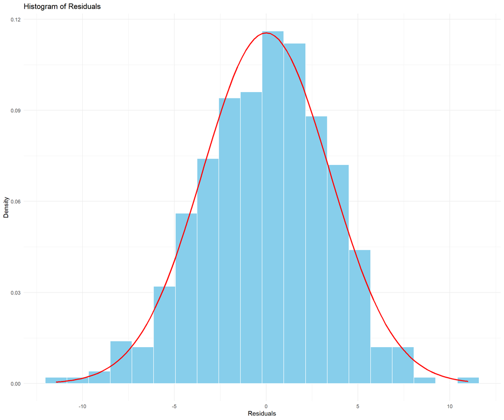

Residual Distribution Plots for Model 2

```r
# Visualize residual distribution


# Histogram of Residuals
ggplot(data.frame(residuals = resid(model2)), aes(x = residuals)) +
  geom_histogram(aes(y = ..density..),
                 bins = 20,
                 fill = "skyblue",
                 color = "white") +
  stat_function(fun = dnorm,
                args = list(mean = mean(resid(model1)), sd = sd(resid(model1))),
                color = "red",
                linewidth = 1) +
  labs(title = "Histogram of Residuals",
       x = "Residuals",
       y = "Density") +
  theme_minimal()
```

```
For confidence bands, please install `qqplotr`.
```

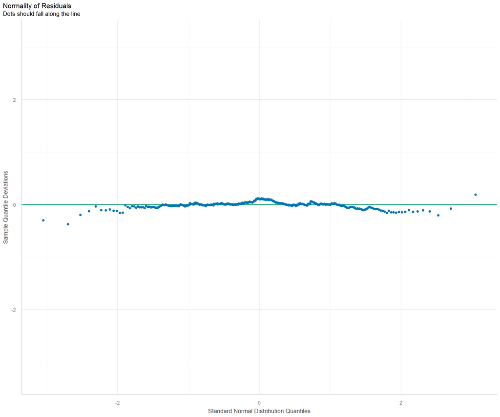

Residual Distribution Plots for Model 2

```r
# A transformed version of a Q–Q plot displayed horizontally
plot(check_normality(model2))
```

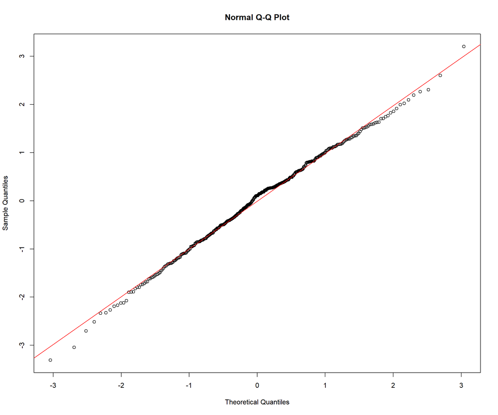

Residual Distribution Plots for Model 2

```r
# Q-Q plot of standardized residuals
qqnorm(rstandard(model2))
qqline(rstandard(model2), col = "red")
```

```r
# Check for outliers or influential points

performance::check_outliers(model2)
```

```
OK: No outliers detected.
- Based on the following method and threshold: cook (0.841).
- For variable: (Whole model)
```

```r
# Extract residuals
residuals <- resid(model2)

# Standardize the residuals
std_residuals <- residuals / sd(residuals)

# Calculate max and min of the standardized residuals
max_std_residual <- max(std_residuals)
min_std_residual <- min(std_residuals)

# Print the results
cat("Max standardized residual:", max_std_residual, "\n")
```

```
Max standardized residual: 3.195864
```

```r
cat("Min standardized residual:", min_std_residual, "\n")
```

```
Min standardized residual: -3.322623
```

```r
#Identify potential outliers in the dataset based on the studentized residuals of the model.
car::outlierTest(model2) # Bonferonni p-value for most extreme observations - observations with a p value lower than the threshold are consider outliers.
```

```
No Studentized residuals with Bonferroni p < 0.05
Largest |rstudent|:
     rstudent unadjusted p-value Bonferroni p
276 -3.347966          0.0008891      0.37609
```

```r
# In this case there are none
```

```r
performance::check_heteroscedasticity(model2)
```

[output not shown]

```r
# Check multicollinearity

performance::check_collinearity(model2)
```

```
# Check for Multicollinearity

Low Correlation

     Term  VIF   VIF 95% CI adj. VIF Tolerance Tolerance 95% CI
 tpstress 1.73 [1.54, 2.00]     1.32      0.58     [0.50, 0.65]
  tpcoiss 1.61 [1.44, 1.86]     1.27      0.62     [0.54, 0.70]
 tlifesat 1.41 [1.27, 1.62]     1.19      0.71     [0.62, 0.79]
  marital 1.22 [1.12, 1.40]     1.10      0.82     [0.72, 0.90]
```

```r
mcresults <-performance::check_collinearity(model2)
```

The data met the assumption of non-zero variances (total optimism =18.66, total perceived stress=32.91, total perception of control=136.26, total life satisfaction = 44.22).

The residual diagnostic plots are shown in Figure 8. The model residuals showed a satisfactory distribution resembling normality. Although minor deviations were observed in the QQ plot indicating slight non-normality in the residuals (max=3.1958635, min=-3.3226229). However, examination of residuals using the guidance of Field, Miles and Field (2012) identified no residual with Cook’s distance greater than 1 and while one potential leverage point was identified, on inspection the observation was considered valid and retained. In addition, the normality test indicated that the residuals did not significantly deviate from normality (p = 0.534). Therefore, the residuals can be considered normally distributed.

Tests to check if the data met the assumption of collinearity indicated that multicollinearity was not a concern (total perceived stress VIF=1.730243, Tolerance = 0.5779535; total perception of control VIF=1.6126458, Tolerance = 0.620099; total life satisfaction VIF=1.4112698, Tolerance = 0.7085817).

The model can be considered to meet the assumptions of multiple linear regression, including linearity, normality of residuals, homoscedasticity, and low multicollinearity, with minimal concerns about influential points. The model diagnostics suggest therefore that the model provides a reliable estimate of the relationship between total optimism, total perceived stress, total perception of control, and total life satisfaction across respondents of different marital status.

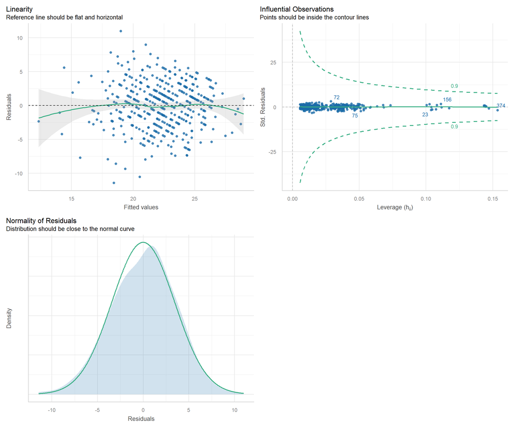

Figure 8 - Diagnostic plots for Model 2

```r
# Overall diagnostic plots
# If using R 4.4.x use
performance::check_model(model2,
  check = c(
    "linearity",
    "homoscedasticity",
    "outliers",
    "collinearity",
    "normality"
  )
)
```

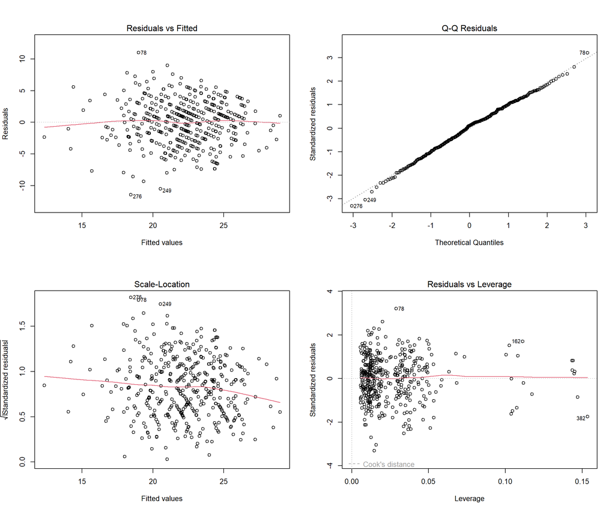

Figure 8 - Diagnostic plots for Model 2

```r
# If using R 4.5.x Show all 4 diagnostic plots in one figure using R basic plots
par(mfrow = c(2, 2))   # 2x2 grid layout
plot(model2)            # Generates: Residuals vs Fitted, Normal Q-Q, Scale-Location, Cook’s distance
```

```r
par(mfrow = c(1, 1))    # Reset layout
```